# Linear Algebra (CpE210A)

## Laboratory 2: Plotting Vectors using NumPy and MatPlotLib

Coded and submitted by:  
*Joaquin, Marc Christopher C.*  
*58010*

### Lab Excercises:

# Part1: Skyline Eagle Fly

You are tasked to make a tracking device for Philippine Eagles at the Philippine Eagle Center at Davao. The tracker sensors only give the longitudinal and latitudinal distance (meters) of the eagle's position relative to their nests which we will treat as the origin of the tracking view. We want to determine the relative **displacement** of the eagle from its nest. It is expected that the eagles will change exactly two times, it can then be assumed that the program will show three displacements. Please make a prototype code using the additional information given below:

Consider the computational algorithm:

Let the eagle's longitudinal and latitudinal be $_{lng}$ and $_{lat}$ respectively.  
Let the eagle's total distance as $dist_{total}$ , displacement be $disp$ , and θ as the direction of the vector.

$_{(Eq.1)}$ $dist_{total}$ = ($lng_{total}$)x^+($lat_{total}$)y^  
${(Eq.2)}$ $disp = \sqrt{dist_x^2 + dist_y^2}$  
${(Eq.3)}$ θ = $arctan(\frac{y}{αx})$

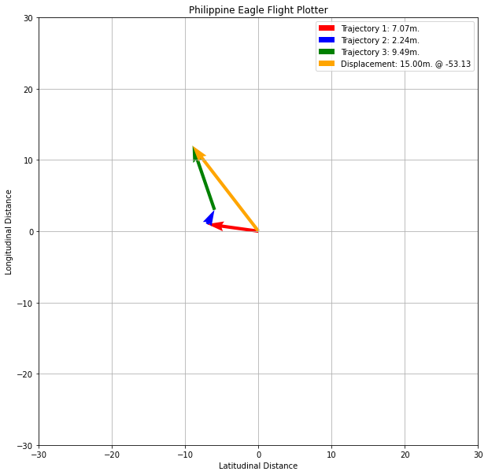

```python
import numpy as np
import matplotlib.pyplot as plt
import matplotlib

%matplotlib inline

def track_eagle(make_figs=True):
    lng = np.random.randint(-10,10, size=3) ## since we don't actually have eagle tracking data we will use
    lat = np.random.randint(-10,10, size=3)  ## random integers for this activity. These two lines will produce
                                             ## a vector with shape of (3,) describing the distances for the
                                             ## eagle's flight.

    dist1 = np.array((lng[0], lat[0]))                            ## setup the array for each vector for the eagle's flight.
    dist2 = np.array((lng[1], lat[1]))
    dist3 = np.array((lng[2], lat[2]))

    dist_total = dist1+dist2+dist3                        ## compute for the resultant vector for the eagle's flight.
    disp = np.linalg.norm(dist_total)                              ## compute for the magnitude of the displacement
    alpha = 10**-6
    theta = np.arctan(dist_total[1]/(dist_total[0]+alpha))                          ## compute for the angle of the displacement. Hint
    theta = np.degrees(theta)                ## convert theta from rad to deg.

    ## Plotting the PH Eagle flight vectors.
    plt.figure(figsize=(10,10))
    plt.title('Philippine Eagle Flight Plotter')
    plt.xlim(-30, 30)
    plt.ylim(-30, 30)
    plt.xlabel('Latitudinal Distance')
    plt.ylabel('Longitudinal Distance')
    plt.grid()
    n = 2

    ### Self-discovery code block (Refer to guide question 2 for the task)

    plt.quiver(0,0, dist1[0], dist1[1],
               angles='xy', scale_units='xy',scale=1, color='red',
               label='Trajectory 1: {:.2f}m.'.format(np.linalg.norm(dist1)))
    plt.quiver(dist1[0], dist1[1], dist2[0], dist2[1],
               angles='xy', scale_units='xy',scale=1, color='blue',
              label='Trajectory 2: {:.2f}m.'.format(np.linalg.norm(dist2)))
    plt.quiver(np.add(dist1[0],dist2[0]), np.add(dist1[1],dist2[1]),
               dist3[0], dist3[1], angles='xy', scale_units='xy',scale=1, color='green',
              label='Trajectory 3: {:.2f}m.'.format(np.linalg.norm(dist3)))
    plt.quiver(0,0, dist_total[0], dist_total[1],
               angles='xy', scale_units='xy',scale=1, color='orange',
              label='Displacement: {:.2f}m. @ {:.2f}'.format(disp, theta))

    plt.legend()

    if make_figs:
        plt.savefig(f'LinAlg-Lab2-PH Eagle-{int(disp)}@{int(theta)}.png', dpi=300)

    plt.show()

## END OF FUNCTION
track_eagle(make_figs=False) ## Let 'make_figs' equal to False during debugging.
```